# Foreigners Fighting For Spots at Top USA Universities

Data was collecting on 400 top tier US university graduate school applicantions (from candidates from India).

I will conduct an anlysis pertaining to how likely an individual is to being admitted to a, world leading, American university for graduate studies.

The credibility of the data may be in question - particularly subjective parameters - however as I have no measure to scrutinize the data generating process I will assume all captured data is accurate.

## dataset

#### Parameters

```
1. GRE Scores (out of 340)
2. TOEFL Scores (out of 120)
3. University Rating (out of 5)
4. Statement of Purpose (out of 5)
5. Letter of Recommendation Strength (out of 5)
6. Undergraduate GPA (out of 10)
7. Research Experience (binary: 0 or 1)
8. Chance of Admit (ranging from 0 to 1) (Dependent variable)
```

https://www.kaggle.com/mohansacharya/graduate-admissions

###### Dataset Citation

Mohan S Acharya, Asfia Armaan, Aneeta S Antony : A Comparison of Regression Models for Prediction of Graduate Admissions, IEEE International Conference on Computational Intelligence in Data Science 2019

# Exploratory Data Analysis (EDA)

lets inspect the data.

There are 400 data points with 8 attributes. (the first column is 'serial number' - which we immediately disregard as it holds no infomation). The data seems to capture all important aspects of a successful graduate school application - as such, we can expect highly-correlation variables.

```python
import numpy as np
import pandas as pd
import matplotlib.pyplot as plt
import statsmodels.api as sm
import seaborn as sns
import scipy.stats as st
from sklearn.linear_model import LogisticRegression
from sklearn.metrics import accuracy_score
import warnings

%matplotlib inline
plt.style.use('seaborn')
warnings.filterwarnings('ignore')
```

```python
data = pd.read_csv('../datasets/graduate-admissions/Admission_Predict.csv')
data = data.iloc[:, 1:9]
data.head()
```

|  | GRE Score | TOEFL Score | University Rating | SOP | LOR | CGPA | Research | Chance of Admit |
| --- | --- | --- | --- | --- | --- | --- | --- | --- |
| 0 | 337 | 118 | 4 | 4.5 | 4.5 | 9.65 | 1 | 0.92 |
| 1 | 324 | 107 | 4 | 4.0 | 4.5 | 8.87 | 1 | 0.76 |
| 2 | 316 | 104 | 3 | 3.0 | 3.5 | 8.00 | 1 | 0.72 |
| 3 | 322 | 110 | 3 | 3.5 | 2.5 | 8.67 | 1 | 0.80 |
| 4 | 314 | 103 | 2 | 2.0 | 3.0 | 8.21 | 0 | 0.65 |

## EDA

The correlation matrix confirms these suspicions, its apparent from the graph below that all the variables are correlated with the response variable ($\hat{Y}$ = probability of admittance) to some degree.

GRE, TOEFL and CGPA unsurprisingly produce the strongest relationships with $\hat{Y}$: they are the official test scores required.

University ranking shows a slight trend - possibly indicative of US universities favouring applications from more credible or familiar institutions.

Statement of Purpose & Letter of Recommendation Strength also show possitive trends, however with a much larger spread (possibly a consequence of the discrete nature of the data limiting possible options). Major universities advocate their desire for well-rounded candidates so we would expect factors outside of academia (capture in these variables, as they are the candidates main avenue of expressing their story and connecting with administrators on an emotional level) to play a pivotal roll in candidate success.

The least eminent variable is whether or not the applicant has expirience with research - it does seem to improve the likelihood of acceptance, but the degree to which may be marginal.

## Multicolinearity

A number of independent variables exhibit substantial correlation (which is intuitively obvious given the nature of the dataset) - a strong candidate for severe-multicolinearity, which may be problematic when distinguishing parameter effects.

## Variable Transformations

Although some variables exhibit large variance, relationships appear linear and as such logorithmic (or other) transformations are unwarranted.

```python
print('Correlation coefficient between Xi and Y: ')
print('')
print(data.corr().iloc[-1,:])
```

```
Correlation coefficient between Xi and Y:

GRE Score            0.802610
TOEFL Score          0.791594
University Rating    0.711250
SOP                  0.675732
LOR                  0.669889
CGPA                 0.873289
Research             0.553202
Chance of Admit      1.000000
Name: Chance of Admit , dtype: float64
```

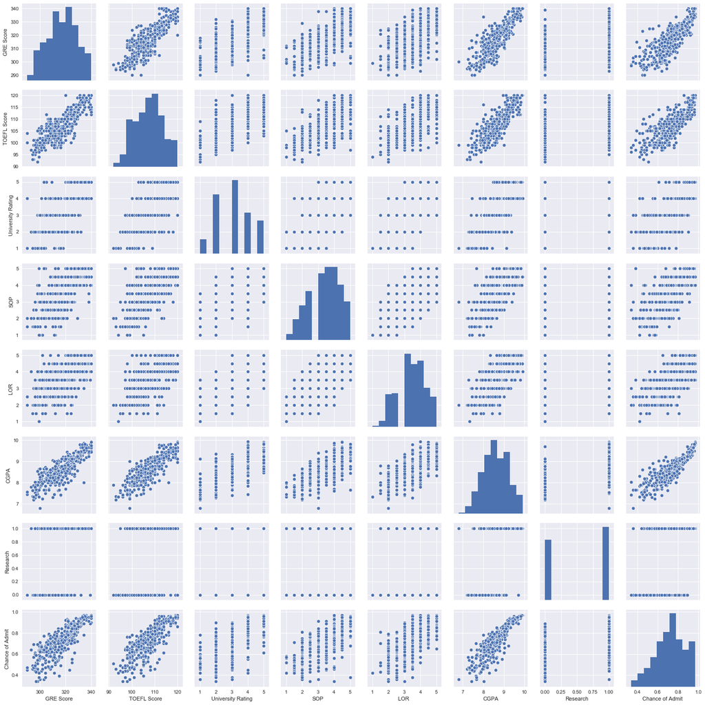

```python
import seaborn as sns
# Basic correlogram
sns.pairplot(data);
```

# Examine variables in Isolation

All of these variables are universal, so it may be helpful to see what kind of test scores (and alikes) these candidates have.

## Test Scores

GRE (Graduate Record Exam) tests critical thinking/reason through reading comprehension and basic mathematics. It is required by most scientific masters/PhD programs.

Possible scores range from: $ 260 \leq x \leq 340$

Global average: $300$

It is clear that these applicants have extremely high test scores: some $340/340$ for GRE; many $80\%+$ GPA students and exceptional grades for TOEFL (an english assessment exam)

The summary provided below gives a good approximation of the range and spread of the strength of applicants.

```python
print('')
print('summary description:')
data.describe()
```

```
summary description:
```

|  | GRE Score | TOEFL Score | University Rating | SOP | LOR | CGPA | Research | Chance of Admit |
| --- | --- | --- | --- | --- | --- | --- | --- | --- |
| count | 400.000000 | 400.000000 | 400.000000 | 400.000000 | 400.000000 | 400.000000 | 400.000000 | 400.000000 |
| mean | 316.807500 | 107.410000 | 3.087500 | 3.400000 | 3.452500 | 8.598925 | 0.547500 | 0.724350 |
| std | 11.473646 | 6.069514 | 1.143728 | 1.006869 | 0.898478 | 0.596317 | 0.498362 | 0.142609 |
| min | 290.000000 | 92.000000 | 1.000000 | 1.000000 | 1.000000 | 6.800000 | 0.000000 | 0.340000 |
| 25% | 308.000000 | 103.000000 | 2.000000 | 2.500000 | 3.000000 | 8.170000 | 0.000000 | 0.640000 |
| 50% | 317.000000 | 107.000000 | 3.000000 | 3.500000 | 3.500000 | 8.610000 | 1.000000 | 0.730000 |
| 75% | 325.000000 | 112.000000 | 4.000000 | 4.000000 | 4.000000 | 9.062500 | 1.000000 | 0.830000 |
| max | 340.000000 | 120.000000 | 5.000000 | 5.000000 | 5.000000 | 9.920000 | 1.000000 | 0.970000 |

## GRE & GPA

The two subsequent distributions provide the spread & mean of GRE and GPA scores, both approximating normality.

```
mu:  316.8075
std:  11.459295080850305
max:  340
min:  290
```

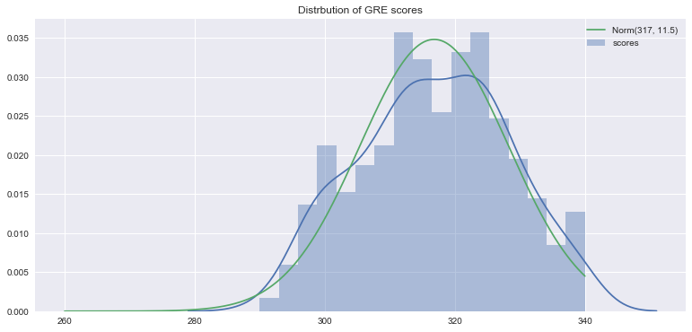

```python
gre = np.array(data['GRE Score'])
print('mu: ', gre.mean())
print("std: ", gre.std())
print('max: ', gre.max())
print('min: ', gre.min())
plt.figure(figsize=(13,6))
plt.title('Distrbution of GRE scores')
sns.distplot(gre,bins=17, label='scores');

# assumed normal
x = np.linspace(260,340, 10000)
dist = st.norm(gre.mean(), gre.std()).pdf(x)
plt.plot(x,dist, label='Norm(317, 11.5)')
plt.legend();
```

```
mu:  8.598925
std:  0.5955712336698272
max:  9.92
min:  6.8
```

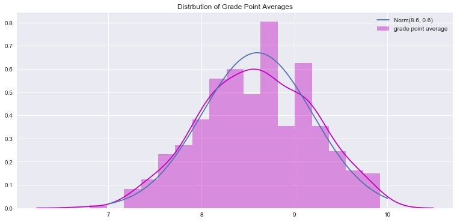

```python
gpa = np.array(data['CGPA'])
print('mu: ', gpa.mean())
print("std: ", gpa.std())
print('max: ', gpa.max())
print('min: ', gpa.min())
plt.figure(figsize=(13,6))
plt.title('Distrbution of Grade Point Averages')
sns.distplot(gpa,bins=17, label='grade point average', color='m');

# assumed normal
x = np.linspace(7,10, 10000)
dist = st.norm(gpa.mean(), gpa.std()).pdf(x)
plt.plot(x,dist, label='Norm(8.6, 0.6)')
plt.legend();
```

# Examination of the dependent variable (Chance of Admission) look like?

Appears roughly uniform above $75\%$, equally dispersed throughout all remaining possible space.

The distribution does, however, seam skewed upwards, as many candidates have a high probability of admission, and drastically drops off at lower levels of $Y$

The highly skewed overall distribution questions the randomness and representativeness of the sample: does the sample comprising of candidates of varying strength? It may be a consequence of weaker candidates not applying for graduate school.

Two plausable explanations are:

```
- the dataset contains mostly top candidates
- the dataset overestimates a candidates chance of adimittance and as such should be discounted
```

The systematic gaps in the histogram are indicative of a discrete process in "Chance of Adittance" allocation.

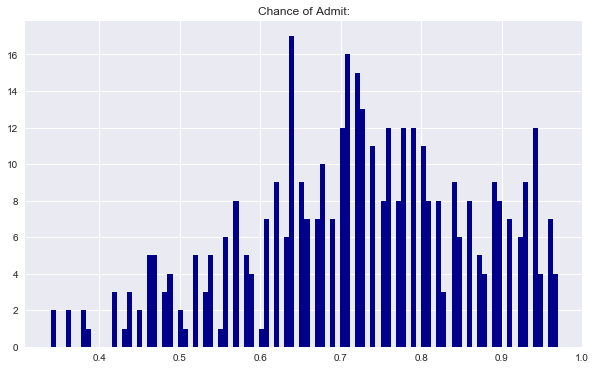

```python
chance = np.array(data['Chance of Admit '])
x = np.linspace(0,100,len(chance))
# plt.figure(figsize=(10,6))
# plt.tick_params(
#     axis='x',          # changes apply to the x-axis
#     which='both',      # both major and minor ticks are affected
#     bottom=False,      # ticks along the bottom edge are off
#     top=False,         # ticks along the top edge are off
#     labelbottom=False)
# plt.scatter(x, chance, c='blue', alpha=.5);


# histogram
plt.figure(figsize=(10,6))
# sns.distplot(chance, bins=100);
plt.title('Chance of Admit:')
plt.hist(chance, bins=100, color='darkblue');
```

## Cumulative Y: Chance of Admit

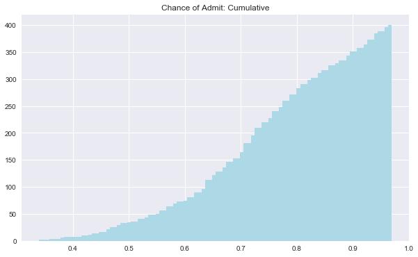

```python
# histogram
plt.figure(figsize=(10,6))
# sns.distplot(chance, bins=100);
plt.title('Chance of Admit: Cumulative')
plt.hist(chance, bins=100, color='lightblue', cumulative=True);
```

# Attributes of Top Candidates

How strong are the best applications?

Suppose we consider a strong application one with the 'Chance of Admittance': $x \geq \widetilde{x}\%$. The function below allows us to readily examine the attributes of a candidate with a $percent \geq \widetilde{x}\%$ chance of admittance.

NOTE: by changing the *percent* variable and re-runing the code cell below you can calculate these metrics for another cutoff percentage.

```python
percent = .80

def descriptive_stats(percentage=0.8):
    """
    Calculate descriptive statistics about candidates with
    a probability of admissions >= percentage.
    """

    if (percentage > 1 or percentage < 0):
        return "please enter a valid percentage"

    else:
        y = data['Chance of Admit ']
        X = data.iloc[:,:-1]


        X_top = X[y > percent]

        proportion_of_dataset = X_top.shape[0]/X.shape[0]

        average_GPA = np.mean(X_top['CGPA'])
        std_GPA = np.std(X_top['CGPA'])
        average_GRE = np.mean(X_top['GRE Score'])
        std_GRE = np.std(X_top['GRE Score'])
        average_TOEFL = np.mean(X_top['TOEFL Score'])
        average_SOP = np.mean(X_top['SOP'])
        average_LOR = np.mean(X_top['LOR '])
        proportion_done_research = np.mean(X_top['Research'])

        results = {
            'proportion of dataset': proportion_of_dataset,
            'average_GPA': average_GPA,
            'std_GPA': std_GPA,
            'average_GRE': average_GRE,
            'std_GRE': std_GRE,
            'average_TOEFL': average_TOEFL,
            'average_SOP': average_SOP,
            'average_LOR': average_LOR,
            'proportion_done_research': proportion_done_research
        }

        return results

print('')
print('Candidates with an %f' %round(percent*100,2), '% of successful admittance earn the following scores: ')
descriptive_stats(percent)
```

```
Candidates with an 80.000000 % of successful admittance earn the following scores:
```

```
{'proportion of dataset': 0.2925,
 'average_GPA': 9.276666666666664,
 'std_GPA': 0.3010267330605274,
 'average_GRE': 328.7350427350427,
 'std_GRE': 6.659474533816447,
 'average_TOEFL': 113.77777777777777,
 'average_SOP': 4.3076923076923075,
 'average_LOR': 4.200854700854701,
 'proportion_done_research': 0.9316239316239316}
```

# Modeling the data

Can we effectively model an applicants "Chance of Adittance"? The highly correlated data suggests so, however the OLS assumptions may prove problematic as a corollary of highly correlated explanatory variables.

## OLS

First, lets fit an OLS and assess the output, in tandem with the correlation matrix, to assess variable importance & possible violations of the OLS assumptions.

```python
# create data to model
y = data['Chance of Admit ']
X = data.iloc[:,:-1]
X = sm.add_constant(X) # add intercept
```

```python
ols = sm.OLS(y,X).fit()
ols.summary2()
```

| Model: | OLS | Adj. R-squared: | 0.800 |
| --- | --- | --- | --- |
| Dependent Variable: | Chance of Admit | AIC: | -1058.7464 |
| Date: | 2019-06-19 14:42 | BIC: | -1026.8147 |
| No. Observations: | 400 | Log-Likelihood: | 537.37 |
| Df Model: | 7 | F-statistic: | 228.9 |
| Df Residuals: | 392 | Prob (F-statistic): | 3.12e-134 |
| R-squared: | 0.803 | Scale: | 0.0040683 |

|  | Coef. | Std.Err. | t | P>\|t\| | [0.025 | 0.975] |
| --- | --- | --- | --- | --- | --- | --- |
| const | -1.2594 | 0.1247 | -10.0972 | 0.0000 | -1.5047 | -1.0142 |
| GRE Score | 0.0017 | 0.0006 | 2.9059 | 0.0039 | 0.0006 | 0.0029 |
| TOEFL Score | 0.0029 | 0.0011 | 2.6797 | 0.0077 | 0.0008 | 0.0051 |
| University Rating | 0.0057 | 0.0048 | 1.1984 | 0.2315 | -0.0037 | 0.0151 |
| SOP | -0.0033 | 0.0056 | -0.5943 | 0.5527 | -0.0142 | 0.0076 |
| LOR | 0.0224 | 0.0055 | 4.0338 | 0.0001 | 0.0115 | 0.0332 |
| CGPA | 0.1189 | 0.0122 | 9.7336 | 0.0000 | 0.0949 | 0.1430 |
| Research | 0.0245 | 0.0080 | 3.0811 | 0.0022 | 0.0089 | 0.0402 |

| Omnibus: | 87.895 | Durbin-Watson: | 0.759 |
| --- | --- | --- | --- |
| Prob(Omnibus): | 0.000 | Jarque-Bera (JB): | 181.191 |
| Skew: | -1.159 | Prob(JB): | 0.000 |
| Kurtosis: | 5.344 | Condition No.: | 13105 |

# 1st Analysis: Combining variables

## Regression Coefficients

The minuscule parameter estimates are a result of the magnitude of the $Y$ variable (which is $\in [0,1]$ bound) - the average change in $Y$ associated with any given parameter would be undoubtled small over this range. I am primarily concerned with variable significance, so this bares no burden, but is worth mentioning.

## Transformations

The initial model is highly significant, boasting an $R^2 = 80\%$. Only two parameters ('University Ranking' and 'SOP') are insignificant predictors.

A visual investigation - via the correlation matrix - hints at some, however weak, relationship between $Y$ and both SOP & University rating. It is plausible that the 'insignificance' diagnostic is a consequence of mathematical assumption violation.

To simplify the data without losing important information, lets combine 'SOP' & 'LOR' as they are on the same scale and capture similar information (the subjective attributes of the candidate). We'll simple sum the variables - creating a new variable.

'University rank' seems to offer a slight advantage if $rank \geq 4$, the difference is marginal for lower intervals. One option would be to binarily classify candidates to separate those above and below $4$, however to keep it simple I will combine this variable with the abovementioned collection.

This approach also corroborates the ethos of *Parsimonious Modelling*, wherein less verbose models are perferred as they reduce computational difficulties and improve interpretability.

```python
new_var_1 = np.sum(X.iloc[:,3:6], axis=1)
X_new = pd.concat([X.iloc[:,0:3],new_var_1, X.iloc[:,6:8]], axis=1)
X_new.head()
```

|  | const | GRE Score | TOEFL Score | 0 | CGPA | Research |
| --- | --- | --- | --- | --- | --- | --- |
| 0 | 1.0 | 337 | 118 | 13.0 | 9.65 | 1 |
| 1 | 1.0 | 324 | 107 | 12.5 | 8.87 | 1 |
| 2 | 1.0 | 316 | 104 | 9.5 | 8.00 | 1 |
| 3 | 1.0 | 322 | 110 | 9.0 | 8.67 | 1 |
| 4 | 1.0 | 314 | 103 | 7.0 | 8.21 | 0 |

```python
ols = sm.OLS(y,X_new).fit()
ols.summary()
```

OLS Regression Results

| Dep. Variable: | Chance of Admit | R-squared: | 0.799 |
| --- | --- | --- | --- |
| Model: | OLS | Adj. R-squared: | 0.797 |
| Method: | Least Squares | F-statistic: | 314.0 |
| Date: | Wed, 19 Jun 2019 | Prob (F-statistic): | 5.64e-135 |
| Time: | 15:02:32 | Log-Likelihood: | 533.24 |
| No. Observations: | 400 | AIC: | -1054. |
| Df Residuals: | 394 | BIC: | -1031. |
| Df Model: | 5 |  |  |
| Covariance Type: | nonrobust |  |  |

|  | coef | std err | t | P>\|t\| | [0.025 | 0.975] |
| --- | --- | --- | --- | --- | --- | --- |
| const | -1.2315 | 0.124 | -9.962 | 0.000 | -1.475 | -0.988 |
| GRE Score | 0.0018 | 0.001 | 2.946 | 0.003 | 0.001 | 0.003 |
| TOEFL Score | 0.0025 | 0.001 | 2.314 | 0.021 | 0.000 | 0.005 |
| 0 | 0.0078 | 0.002 | 3.938 | 0.000 | 0.004 | 0.012 |
| CGPA | 0.1203 | 0.012 | 9.772 | 0.000 | 0.096 | 0.144 |
| Research | 0.0239 | 0.008 | 2.986 | 0.003 | 0.008 | 0.040 |

| Omnibus: | 92.038 | Durbin-Watson: | 0.735 |
| --- | --- | --- | --- |
| Prob(Omnibus): | 0.000 | Jarque-Bera (JB): | 190.370 |
| Skew: | -1.212 | Prob(JB): | 4.59e-42 |
| Kurtosis: | 5.356 | Cond. No. | 1.29e+04 |

Warnings:  
[1] Standard Errors assume that the covariance matrix of the errors is correctly specified.  
[2] The condition number is large, 1.29e+04. This might indicate that there are  
strong multicollinearity or other numerical problems.

### Results

All explanatory variables are now significant at a $5\%$ level of significance. Both $R^2$ and $R_{adjusted}^2$ have slightly decreased - although only marginally. The model is highly significant.

# Logistic Regression

A logit model may provide superior performance, as the data is $\in [0,1]$ bound, so modeling $Y$ as a $\ln(odds)$ may be appropriate.

#### Lets compare the fit of a regression regression and a logit

## Regular OLS Regression

```
Correlation between y & yhat:

[[1.         0.89407239]
 [0.89407239 1.        ]]
```

| Model: | OLS | Adj. R-squared: | 0.797 |
| --- | --- | --- | --- |
| Dependent Variable: | Chance of Admit | AIC: | -1054.4756 |
| Date: | 2019-06-19 15:02 | BIC: | -1030.5268 |
| No. Observations: | 400 | Log-Likelihood: | 533.24 |
| Df Model: | 5 | F-statistic: | 314.0 |
| Df Residuals: | 394 | Prob (F-statistic): | 5.64e-135 |
| R-squared: | 0.799 | Scale: | 0.0041322 |

|  | Coef. | Std.Err. | t | P>\|t\| | [0.025 | 0.975] |
| --- | --- | --- | --- | --- | --- | --- |
| const | -1.2315 | 0.1236 | -9.9622 | 0.0000 | -1.4745 | -0.9885 |
| GRE Score | 0.0018 | 0.0006 | 2.9455 | 0.0034 | 0.0006 | 0.0030 |
| TOEFL Score | 0.0025 | 0.0011 | 2.3141 | 0.0212 | 0.0004 | 0.0047 |
| 0 | 0.0078 | 0.0020 | 3.9383 | 0.0001 | 0.0039 | 0.0117 |
| CGPA | 0.1203 | 0.0123 | 9.7722 | 0.0000 | 0.0961 | 0.1445 |
| Research | 0.0239 | 0.0080 | 2.9865 | 0.0030 | 0.0082 | 0.0397 |

| Omnibus: | 92.038 | Durbin-Watson: | 0.735 |
| --- | --- | --- | --- |
| Prob(Omnibus): | 0.000 | Jarque-Bera (JB): | 190.370 |
| Skew: | -1.212 | Prob(JB): | 0.000 |
| Kurtosis: | 5.356 | Condition No.: | 12890 |

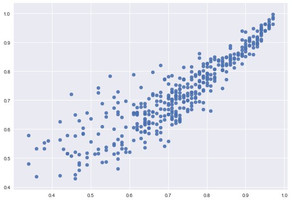

```python
model = sm.OLS(y, X_new)
reg = model.fit()
reg.summary2()
yhat = reg.predict(X_new)


print('Correlation between y & yhat: ')
print('')
print(np.corrcoef([y,yhat]))
print('')
plt.figure(figsize=(10,7))
plt.scatter(y, yhat, alpha=0.9);

reg.summary2()
```

## Logistic Regression

```
Optimization terminated successfully.
         Current function value: 0.459122
         Iterations 6

Correlation between y & yhat:

[[1.         0.88189913]
 [0.88189913 1.        ]]
```

| Model: | Logit | Pseudo R-squared: | -1.671 |
| --- | --- | --- | --- |
| Dependent Variable: | Chance of Admit | AIC: | 379.2974 |
| Date: | 2019-06-19 15:03 | BIC: | 403.2462 |
| No. Observations: | 400 | Log-Likelihood: | -183.65 |
| Df Model: | 5 | LL-Null: | -68.749 |
| Df Residuals: | 394 | LLR p-value: | 1.0000 |
| Converged: | 1.0000 | Scale: | 1.0000 |
| No. Iterations: | 6.0000 |  |  |

|  | Coef. | Std.Err. | z | P>\|z\| | [0.025 | 0.975] |
| --- | --- | --- | --- | --- | --- | --- |
| const | -9.8155 | 4.4394 | -2.2110 | 0.0270 | -18.5166 | -1.1144 |
| GRE Score | 0.0104 | 0.0208 | 0.5003 | 0.6169 | -0.0304 | 0.0513 |
| TOEFL Score | 0.0154 | 0.0392 | 0.3922 | 0.6949 | -0.0614 | 0.0921 |
| 0 | 0.0411 | 0.0716 | 0.5744 | 0.5657 | -0.0991 | 0.1813 |
| CGPA | 0.6341 | 0.4311 | 1.4710 | 0.1413 | -0.2108 | 1.4791 |
| Research | 0.1253 | 0.2797 | 0.4481 | 0.6541 | -0.4229 | 0.6736 |

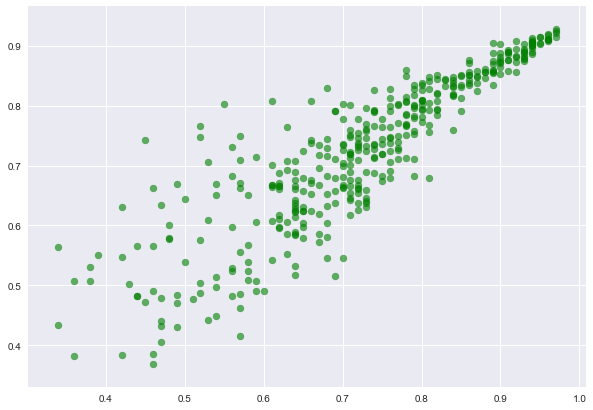

```python
model = sm.Logit(y, X_new)
logit = model.fit()
logit.summary2()
yhat = logit.predict(X_new)

print('')
print('Correlation between y & yhat: ')
print('')
print(np.corrcoef([y,yhat]))
plt.figure(figsize=(10,7))
plt.scatter(y, yhat, c='g', alpha=0.6);

logit.summary2()
```

## Results

Both models (OLS & Logit) fit the data well. The logit cannot be readily interpreted as the package is designed to take binary response variable input, however high correlation between $Y$ & $\hat{Y}$ (given an uncorrected SSR ($SS(X)$)) as well as the scatter plot imply a the data is modelled well.

# sklearn Logistic Regression

For good measure I will also fit a logit using SKlearn. This requires binary input and as such the function below allows the user to specify a cutoff percentage, where $x \geq x\%$ chance of admittance, and then fit a logit model to classify the data as *'above'* or *'below'* this criteria.

The function takes a additional (optional) argument, including a list of a new candidates scores will compute whether or not the candidate is accepted according to the model.

## Results

The SKlearn implementation produces a very high 'accuracy rate', however this my be viewed precautionarily as is not neccessarily indicative of a high performing model (have not considered Specificity or Sensitivity).

```python
cutoff = 0.8

def will_you_get_in(predictions=None, cutoff=0.8):
    """
    fit a logistic regression classifing the candidates as 'Accepted' or 'Rejected'
    above or below the cutoff value.

    cutoff: the lowest acceptable value
    predictions: new data to forecast based on the trained model (takes a list)
    """
    y_bin = y> cutoff

    sk_logit = LogisticRegression()
    sk_logit.fit(X_new, y_bin)
    predicted_classes = sk_logit.predict(X_new)
    accuracy = accuracy_score(y_bin.values.flatten(),predicted_classes)
    parameters = sk_logit.coef_

    if predictions is not None:
        my_predictions = sk_logit.predict([predictions])
    else:
        my_predictions = 'NA'

    results = {
        'accuracy': accuracy,
        'cutoff': cutoff,
        'parameters': parameters,
        'my_predictions': my_predictions[0]
    }

    return results

will_you_get_in([1, 320, 112, 11, 8.0, 1])
```

```
{'accuracy': 0.9175,
 'cutoff': 0.8,
 'parameters': array([[-1.05753279, -0.15896774,  0.19031053,  0.60876425,  2.61964744,
          2.23927558]]),
 'my_predictions': False}
```

# Weighted Least Squares

Reverting to the graphical representation of the plotted $Y$ vs $\hat{Y}$ values, the results seem to exhibit Heteroscedasticity (unequal variance). WLS (weighted least squares) can be utilized to mitigate these effects by under-weighted the influence of high variance response variables.

The variance appears large at lower values of $Y$, as the distribution narrows in towards $Y=1$.

I have applied a simple weighting mechanism wherein more weight is assigned in 4 discrete intervals. A more sophisticated weighting mechanism may yield better results.

```
[[1.         0.89407239]
 [0.89407239 1.        ]]
```

| Model: | WLS | Adj. R-squared: | 0.797 |
| --- | --- | --- | --- |
| Dependent Variable: | Chance of Admit | AIC: | -1054.4756 |
| Date: | 2019-06-19 15:16 | BIC: | -1030.5268 |
| No. Observations: | 400 | Log-Likelihood: | 533.24 |
| Df Model: | 5 | F-statistic: | 314.0 |
| Df Residuals: | 394 | Prob (F-statistic): | 5.64e-135 |
| R-squared: | 0.799 | Scale: | 0.0041322 |

|  | Coef. | Std.Err. | t | P>\|t\| | [0.025 | 0.975] |
| --- | --- | --- | --- | --- | --- | --- |
| const | -1.2315 | 0.1236 | -9.9622 | 0.0000 | -1.4745 | -0.9885 |
| GRE Score | 0.0018 | 0.0006 | 2.9455 | 0.0034 | 0.0006 | 0.0030 |
| TOEFL Score | 0.0025 | 0.0011 | 2.3141 | 0.0212 | 0.0004 | 0.0047 |
| 0 | 0.0078 | 0.0020 | 3.9383 | 0.0001 | 0.0039 | 0.0117 |
| CGPA | 0.1203 | 0.0123 | 9.7722 | 0.0000 | 0.0961 | 0.1445 |
| Research | 0.0239 | 0.0080 | 2.9865 | 0.0030 | 0.0082 | 0.0397 |

| Omnibus: | 92.038 | Durbin-Watson: | 0.735 |
| --- | --- | --- | --- |
| Prob(Omnibus): | 0.000 | Jarque-Bera (JB): | 190.370 |
| Skew: | -1.212 | Prob(JB): | 0.000 |
| Kurtosis: | 5.356 | Condition No.: | 12890 |

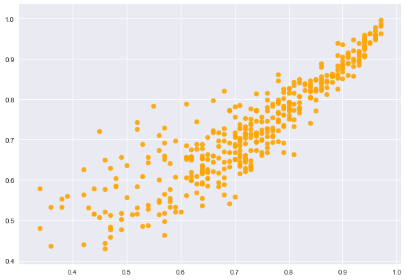

```python
# Weight OLS
# large variance for lower scores, therefore assigning it a lower weight may improve results

w = (np.concatenate([[.1,.1,.1,.1,.1],np.ones(round(len(y)*0.3))*0.2, np.ones(round(len(y)*0.3))*0.3, np.ones(round(len(y)*0.3))*3]))


model = sm.WLS(y, X_new, w=1./(w ** 2))
weightLeastSquares = model.fit()
summary = weightLeastSquares.summary2()
yhat = weightLeastSquares.predict(X_new)


print(np.corrcoef([y,yhat]))
plt.figure(figsize=(10,7))
plt.scatter(y, yhat, c='orange', alpha=0.9);

summary
```

# Artificial Neural Network

Since the primary objective is the model is prediction - and not explicitly individual variable interpretation - an ANN may offer superior predictive performance.

Since an ANN is a black-box model, all variables will be used, without manipulation. The $X$ matrix is redefined as the constant variable is of no relevance.

Features are scaled to avoid over/under-weighting of importance. Data is split into training and test data.

## ANN Structure

A simple ANN is constructed, consisting of:

```
- An input layer
- Three dense hidden layers consisting of 120, 60 & 35 nodes respectively (utilizing a 'relu' activation function)
- An output node with no activation function (tested with a linear activation)
```

```python
import keras
from keras.layers import Dense
from keras.models import Sequential
from keras.utils import to_categorical
from keras.optimizers import SGD
from keras.callbacks import EarlyStopping
from sklearn.metrics import mean_squared_error

import tensorflow
```

```python
# X matrix
X_ANN = data.iloc[:,:-1]


# split to training and test set
from sklearn.model_selection import train_test_split
X_train, X_test, y_train, y_test = train_test_split(X_ANN, y, test_size = 0.2)

# feature scaling
from sklearn.preprocessing import MinMaxScaler
sc = StandardScaler()
X_train = sc.fit_transform(X_train)
X_test = sc.transform(X_test)


# Define the model
ANN = Sequential()

# No. of predictors / input layer
n_cols = X_train.shape[1]
input_shape = (n_cols, )


# Build hidden layers / output layer
ANN.add(Dense(120, activation='relu', input_shape=input_shape))
ANN.add(Dense(60, activation='relu'))
ANN.add(Dense(35, activation='relu'))
ANN.add(Dense(1))


# Compile the model
ANN.compile(optimizer='adam', loss='mean_squared_error')

# Define early stopping (on lack of improvement per epoch)
early_stopping_monitor = EarlyStopping(patience=3)

# Fit the model
fit = ANN.fit(X_train, y_train, epochs=30, validation_split=0.3, callbacks=[early_stopping_monitor], verbose=False)

# predictions
y_pred = ANN.predict(X_test)

ANN.summary()

ANN.evaluate(X_test, y_test)
```

```
_________________________________________________________________
Layer (type)                 Output Shape              Param #
=================================================================
dense_229 (Dense)            (None, 120)               960
_________________________________________________________________
dense_230 (Dense)            (None, 60)                7260
_________________________________________________________________
dense_231 (Dense)            (None, 35)                2135
_________________________________________________________________
dense_232 (Dense)            (None, 1)                 36
=================================================================
Total params: 10,391
Trainable params: 10,391
Non-trainable params: 0
_________________________________________________________________
```

```
0.007094272039830684
```

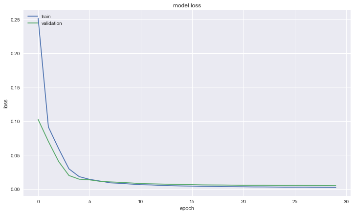

```python
# print(fit.history.keys())
# "Loss"
plt.figure(figsize=(12,7))
plt.plot(fit.history['loss'])
plt.plot(fit.history['val_loss'])
plt.title('model loss')
plt.ylabel('loss')
plt.xlabel('epoch')
plt.legend(['train', 'validation'], loc='upper left')
plt.show()
```

```
R Squared:  0.6041664077981185

correlation between Y & Yhat:

[[1.         0.89407239]
 [0.89407239 1.        ]]
```

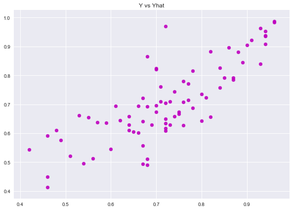

```python
# custom R2-score metrics for keras backend


from sklearn.metrics import r2_score

print('R Squared: ', r2_score(y_test, y_pred))
print('')
print('correlation between Y & Yhat: ')
print('')
print(np.corrcoef([y,yhat]))
print('')
plt.figure(figsize=(10,7))
plt.title('Y vs Yhat')
plt.scatter(y_test, y_pred, c='m', alpha=0.9);
```

```python
hist = pd.DataFrame(fit.history)
hist['epoch'] = fit.epoch
hist.tail()
```

|  | val_loss | loss | epoch |
| --- | --- | --- | --- |
| 25 | 0.005226 | 0.002701 | 25 |
| 26 | 0.005182 | 0.002723 | 26 |
| 27 | 0.005124 | 0.002598 | 27 |
| 28 | 0.004984 | 0.002473 | 28 |
| 29 | 0.004926 | 0.002366 | 29 |

## ANN Evaluation

Despite minimizing the loss with an array of different model specifications, the ANN does not seem to compare to the general linear models and thus will be not considered further.

At best, the ANN produces comparable metrics ($R^2$, $SS(X)$, $MSE$) but at the expense of computational efficiency and without being able to derive meaning from individual predictors (as it is a black box model).

# Predictions

Finally, lets predict the outcome of a new candidates application. The function below allows a user to specify their scores & the 'chance of admittions' considered successful (for the sklearn logit model), then returns:

```
- The predicted outcome Y (chance of admittance) using OLS
- The predicted outcome Y leveraging Logit
- The predicted binary response ('Accepted/Rejected') using sklearn Logit
```

The Weighted Least Squares & ANN are unnecessary to consider further.

Note: The verbose nature of the function is so that is can run without having stored the above results in memory.

## Multicolinearity

Since the primary purpose of the function is prediction, we are not concerned with multicolinearity and will include all variables.

### TOEFL & Uni Rating

The models are generated on the variables submitted; omitting pertinent information may obscure the results so most variables are required, however *'TOEFL'* & *'University Rating'* are optional as TOEFL is are not required with most application & University Rating seems of minor relevance.

```python
def my_probability(gre, sop, lor, gpa, research, toefl=None, uni_rating=None, acceptance_probability=0.8):
    """
    Requires input consistent with actualy score boundaries
    """
    # Define model data
    y = data['Chance of Admit ']
    X = data.iloc[:,:-1]
    X = sm.add_constant(X)
    X_ = X.drop(['TOEFL Score', 'University Rating'], axis=1)


    # Define user data
    Xn = [1, gre, sop, lor, gpa, research]

    if toefl is not None:
        Xn.append(toefl)
        X_['toefl'] = X['TOEFL Score']

    if uni_rating is not None:
        Xn.append(uni_rating)
        X_['University Rating'] = X['University Rating']


    # OLS
    model = sm.OLS(y, X_)
    reg = model.fit()
    yhat_OLS = reg.predict(Xn)


    # Logit
    model = sm.Logit(y, X_)
    logit = model.fit()
    yhat_logit = logit.predict(Xn)


    # SKlearn Logit
    y_bin = y> acceptance_probability

    sk_logit = LogisticRegression()
    sk_logit.fit(X_, y_bin)
    yhat_sklearn = sk_logit.predict([Xn])


    results = {
        'OLS prediction': yhat_OLS,
        'Logit prediction': yhat_logit,
        'Logit Sklearn': yhat_sklearn,
    }

    return results




my_probability(gre=330, uni_rating=3, sop=4, lor=4, gpa=8.5, research=1)
```

```
Optimization terminated successfully.
         Current function value: 0.458980
         Iterations 6
```

```
{'OLS prediction': array([0.76491135]),
 'Logit prediction': array([0.78388106]),
 'Logit Sklearn': array([False])}
```

# Thanks for reading! :)